# TILS

```r
if(!require("SEtools")) BiocManager::install("SEtools")
require(SEtools)
require(SummarizedExperiment)
require(tidyverse)
require(GSVA)
require(ggplot2)
library(limma)
```

```r
#check chemokines CXCL10 or CCL5
TCandTILS.se <- readRDS("/export/scratch/pangelin/HUG/brca_nov2021/dgea/salmon/rdata/step1_nonfiltered_salmon.merged.TCandTILS.gene_counts.rds")
TCandTILS.se$MENOPAUSAL_STATUS <- ordered(TCandTILS.se$MENOPAUSAL_STATUS, levels = c("premenopausal","menopausal"))
genes <- c("CXCL10", "CCL5")
genesID <- rowData(TCandTILS.se) %>% as.data.frame %>% filter(geneName %in% genes) %>% pull(gene_id)
assay(TCandTILS.se,1) <- as.matrix(assay(TCandTILS.se,1))
to.plot.df <- meltSE(TCandTILS.se, genesID, assayName = "counts", colDat.columns = "MENOPAUSAL_STATUS", rowDat.columns = "geneName")
ggplot(to.plot.df, aes(MENOPAUSAL_STATUS, counts, fill=MENOPAUSAL_STATUS)) + geom_boxplot() + geom_jitter() +
    facet_wrap(~geneName, scale="free") + theme_classic() + scale_fill_manual(values = c("green3", "red2"))
```

```r
SEobj <- readRDS(file.path(params$data_dir,params$file_name))
SEobj$MENOPAUSAL_STATUS <- ordered(SEobj$MENOPAUSAL_STATUS, levels = c("premenopausal","menopausal"))
signatures <- list()
```

**WARNING: some signature genes maybe too lowly expressed (undetected) in the dataset, therefore missing from the heatmaps**

## ESR1, PGR, TNFRSF11A, TNFRSF11B

```r
genes <- c("ESR1", "PGR", "TNFRSF11A", "TNFRSF11B")
genesID <- rowData(SEobj) %>% as.data.frame %>% filter(geneName %in% genes) %>% pull(gene_id)
```

```r
to.plot.df <- meltSE(SEobj, genesID, assayName = "vst", colDat.columns = "MENOPAUSAL_STATUS", rowDat.columns = "geneName")
```

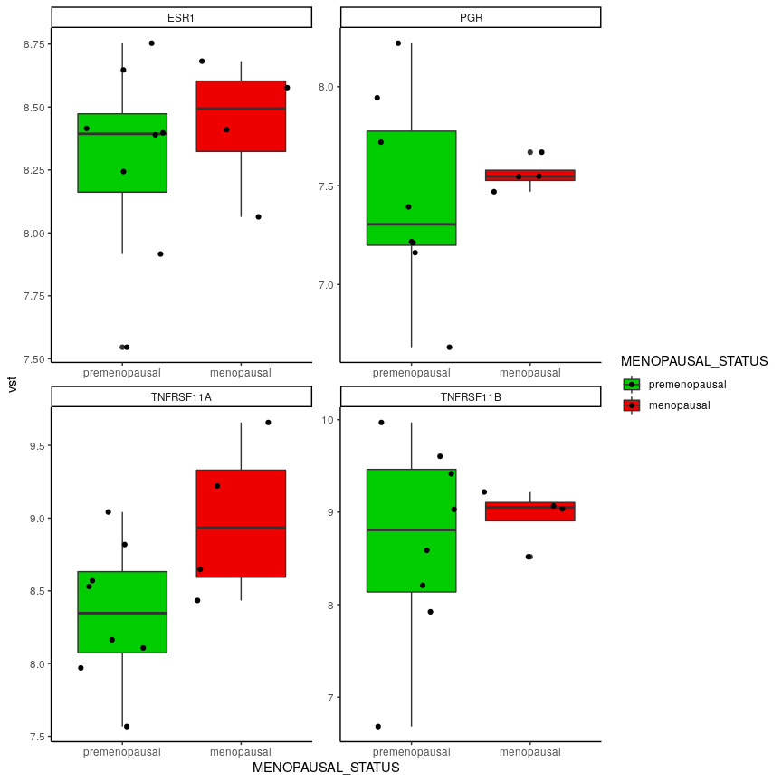

```r
ggplot(to.plot.df, aes(MENOPAUSAL_STATUS, vst, fill=MENOPAUSAL_STATUS)) + geom_boxplot() + geom_jitter() +
    facet_wrap(~geneName, scale="free") + theme_classic() + scale_fill_manual(values = c("green3", "red2"))
```

## CD9, MARCO, FAP, SPP1

```r
genes <- c("CD9", "MARCO", "FAP", "SPP1")
genesID <- rowData(SEobj) %>% as.data.frame %>% filter(geneName %in% genes) %>% pull(gene_id)
```

```r
to.plot.df <- meltSE(SEobj, genesID, assayName = "vst", colDat.columns = "MENOPAUSAL_STATUS", rowDat.columns = "geneName")
```

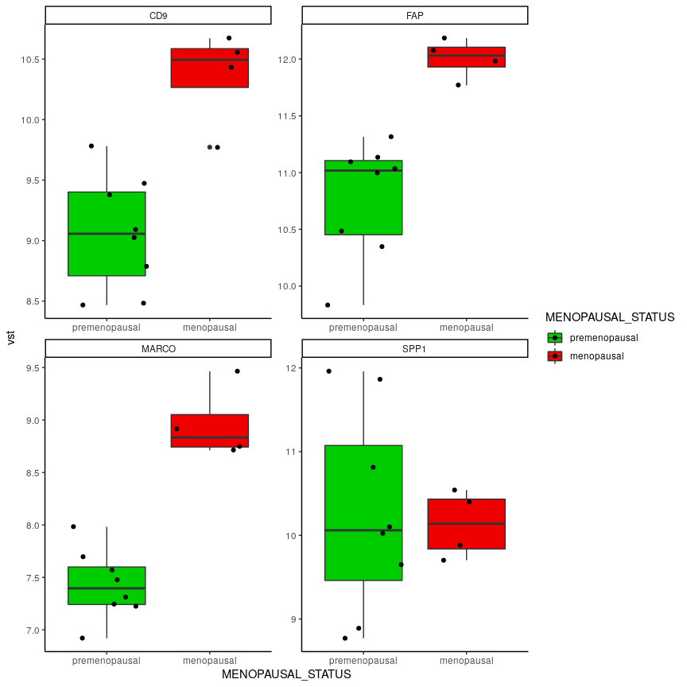

```r
ggplot(to.plot.df, aes(MENOPAUSAL_STATUS, vst, fill=MENOPAUSAL_STATUS)) + geom_boxplot() + geom_jitter() +
    facet_wrap(~geneName, scale="free")  + theme_classic() + scale_fill_manual(values = c("green3", "red2"))
```

## Chemokine signature (Messina 2012)

This 12-chemokine predicts the presence of lymph node-like structures, containing CD20+ B cell follicles. Genes: CCL18, CCL19, CCL2, CCL21, CCL3, CCL4, CCL5, CCL8, CXCL10, CXCL11, CXCL11_2, CXCL13, CXCL9

```r
genes <- c("CCL18", "CCL19", "CCL2", "CCL21", "CCL3", "CCL4", "CCL5", "CCL8", "CXCL10", "CXCL11", "CXCL11_2", "CXCL13", "CXCL9")
signatures$Messina_chemokine <- rowData(SEobj) %>% as.data.frame %>% filter(geneName %in% genes) %>% pull(gene_id)
```

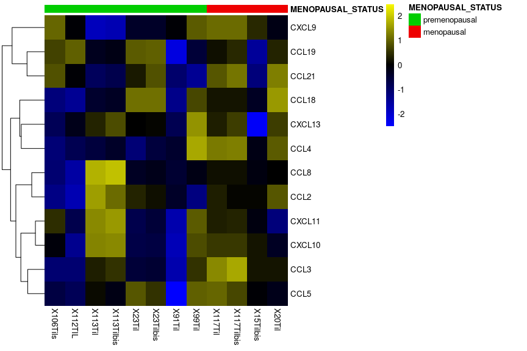

```r
SEobj2 <- SEobj[signatures$Messina_chemokine,order(SEobj$MENOPAUSAL_STATUS)]
rownames(SEobj2) <- rowData(SEobj2)$geneName
sehm(SEobj2, rownames(SEobj2),assayName="vst", do.scale=TRUE, anno_columns = "MENOPAUSAL_STATUS",
     cluster_cols = params$cluster_cols, cluster_rows = T, show_colnames = T, anno_colors = list(MENOPAUSAL_STATUS=c(premenopausal="green3", menopausal="red2"))) # , anno_rows="meanTPM"
```

## Tertiary lymphoid structures (cabrita 2020).

Known TLS marker genes: BCL6 CD86 CXCR4 LAMP3 SELL CCR7 CXCL13 CCL21 CCL19

```r
genes <- c("BCL6", "CD86", "CXCR4", "LAMP3", "SELL", "CCR7", "CXCL13", "CCL21", "CCL19")
signatures$Cabrita_tls <- rowData(SEobj) %>% as.data.frame %>% filter(geneName %in% genes) %>% pull(gene_id)
```

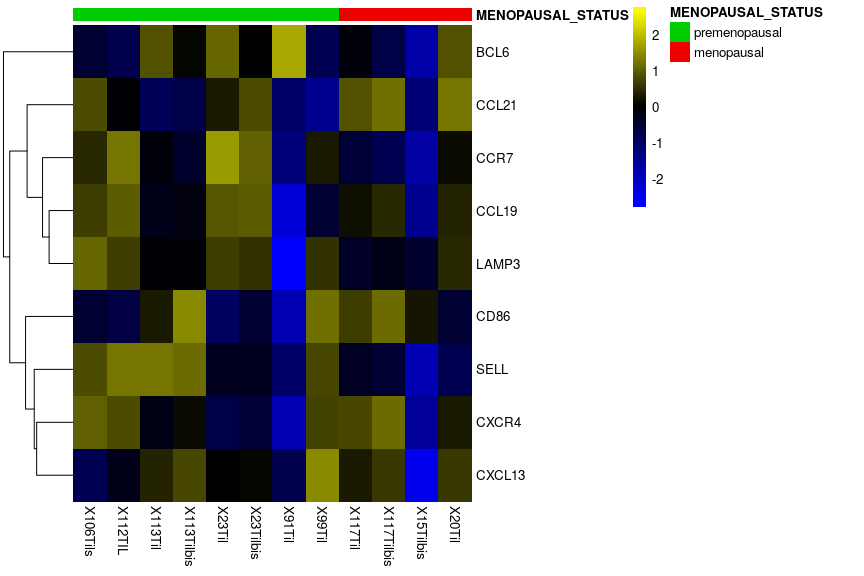

```r
SEobj2 <- SEobj[signatures$Cabrita_tls,order(SEobj$MENOPAUSAL_STATUS)]
rownames(SEobj2) <- rowData(SEobj2)$geneName
sehm(SEobj2, rownames(SEobj2),assayName="vst", do.scale=TRUE, anno_columns = "MENOPAUSAL_STATUS",
     cluster_cols = params$cluster_cols, cluster_rows = T, show_colnames = T, anno_colors = list(MENOPAUSAL_STATUS=c(premenopausal="green3", menopausal="red2"))) # , anno_rows="meanTPM"
```

## Immune Response Dominated by Myeloid and B Cells (Goff CCR 2022)

NanoString followed by clustering with KEGG pathway analysis.  
Signatures: cell proliferation, myeloid inflammatory, B cells, Ag presentation, NK cells https://aacrjournals.org/view-large/figure/14118087/1701fig5.jpeg

```r
genes.df <- data.frame(geneName = c("ANXA2", "BRAF", "BRIC5", "MKI67",
                     "CXCL2", "S100A8", "S100A9",
                     "HLA-DMA", "HLA-DMB", "HLA-DPB1", "HLA-DRA", "CD14", "CD86", "MRC1", "MARCO", "ITGAM", "CTSB", "CTSS", "FCGR2B",
                     "FCGR2B", "LILRB4", "SYK",
                     "SYK", "HCST", "HLA-G", "TYROBP"),
             pathway = c(rep("Cell proliferation",4),
                         rep("Myeloid inflammatory",3),
                         rep("Agpresentation",12),
                         rep("B cells",3),
                         rep("NK cells",4)))
genes <- rowData(SEobj) %>% as.data.frame %>% filter(geneName %in% genes.df$geneName) # %>% select(geneName, gene_id)
genes <- merge(genes,genes.df)
for (n in unique(genes.df$pathway)) {
  signatures[[paste0("Goff_",n)]] <- genes[which(genes.df$pathway==n),"gene_id"]
}
```

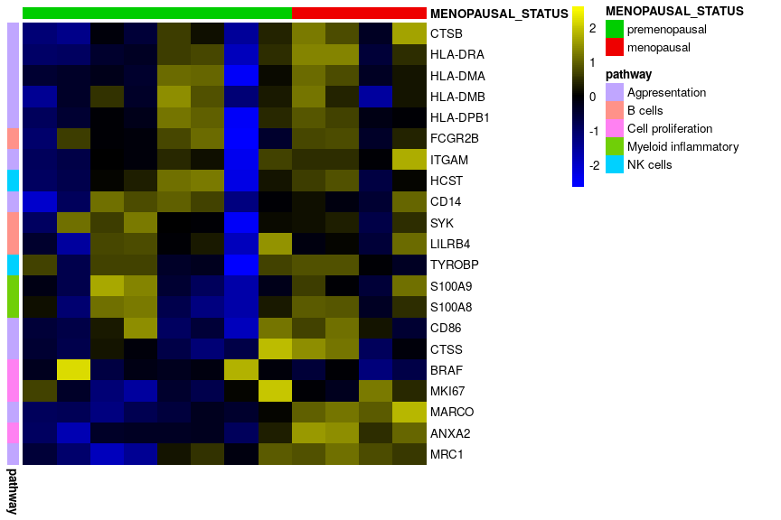

```r
SEobj.selected <- SEobj[genes$gene_id,order(SEobj$MENOPAUSAL_STATUS)]
rowData(SEobj.selected) <- genes
SEobj.selected <- SEobj.selected[unique(genes$gene_id),]
rownames(SEobj.selected) <- rowData(SEobj.selected)$geneName
sehm(SEobj.selected, assayName="vst", genes = genes$geneName, do.scale=TRUE, anno_columns = "MENOPAUSAL_STATUS",
     cluster_cols = params$cluster_cols, cluster_rows = F, anno_rows = "pathway", anno_colors = list(MENOPAUSAL_STATUS=c(premenopausal="green3", menopausal="red2")))
```

## Characterization of tumor infiltrating myeloid cells (zhang cell 2020)

13 myeloid subsets including tumor-associated macrophages (TAMs) and dendritic cells (DCs)

Load and filter gene lists

```r
zhang_markers_10x <- read_delim("/export/scratch/pangelin/HUG/brca_nov2021/dgea/zhang_markers_10x.csv", delim = ";", escape_double = FALSE, trim_ws = TRUE)
zhang_markers_smartseq <- read_delim("/export/scratch/pangelin/HUG/brca_nov2021/dgea/zhang_markers_smartseq.csv", delim = ";", escape_double = FALSE, trim_ws = TRUE)
```

```r
if(params$verbose){
zhang_markers_10x %>% filter(AUC > 0.8) %>% nrow
zhang_markers_10x %>% filter(AUC > 0.8) %>% pull("Myeloid cluster") %>% table
zhang_markers_smartseq %>% filter(AUC > 0.8) %>% nrow
zhang_markers_smartseq %>% filter(AUC > 0.8) %>% pull("Myeloid cluster") %>% table
}
zhang_markers_10x_filt <- zhang_markers_10x %>% filter(AUC > 0.8)
zhang_markers_smartseq_filt <- zhang_markers_smartseq %>% filter(AUC > 0.8)
common_genes <- intersect(zhang_markers_10x_filt$`Gene symbol`,zhang_markers_smartseq_filt$`Gene symbol`)
zhang_markers_10x_filt <- zhang_markers_10x_filt %>% filter(`Gene symbol` %in% common_genes)
table(zhang_markers_10x_filt$`Myeloid cluster`)
```

```
##
## hM01_Mast-TPSAB1  hM02_pDC-LILRA4   hM03_cDC2-CD1C  hM04_cDC1-BATF3
##               22               17                7               10
##   hM05_Mono-CD14   hM06_Mono-CD16 hM08_Macro-NLRP3  hM09_Macro-PLTP
##                6                7               12               14
##  hM10_Macro-IL1B    hM12_TAM-C1QC    hM13_TAM-SPP1
##               19               16                9
```

```r
# table(zhang_markers_10x_filt$`Gene symbol`, zhang_markers_10x_filt$`Myeloid cluster`)
```

Select markers that are unique to each cluster

```r
my_markers <- rowSums(table(zhang_markers_10x_filt$`Gene symbol`, zhang_markers_10x_filt$`Myeloid cluster`))
```

```r
for (n in unique(zhang_markers_10x_filt$`Myeloid cluster`)) {
  ngenes <- zhang_markers_10x_filt[which(zhang_markers_10x_filt$`Myeloid cluster`==n),] %>% pull("Gene symbol")
  signatures[[paste0("Zhang_",n)]] <- rowData(SEobj) %>% as.data.frame %>% filter(geneName %in% ngenes) %>% pull(gene_id)
}
```

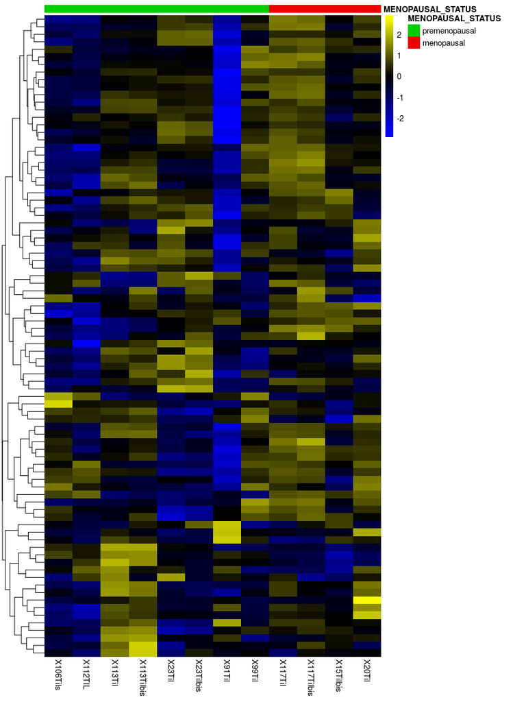

```r
genes <- unique(zhang_markers_10x_filt$`Gene symbol`)
SEobj2 <- SEobj[rowData(SEobj) %>% as.data.frame %>% filter(geneName %in% genes) %>% pull(gene_id),order(SEobj$MENOPAUSAL_STATUS)]
rownames(SEobj2) <- rowData(SEobj2)$geneName
sehm(SEobj2, rownames(SEobj2),assayName="vst", do.scale=TRUE, anno_columns = "MENOPAUSAL_STATUS",
     cluster_cols = params$cluster_cols, cluster_rows = T, show_colnames = T, anno_colors = list(MENOPAUSAL_STATUS=c(premenopausal="green3", menopausal="red2"))) # , anno_rows="meanTPM"
```

## Characterization of myeloid cells: suppressive vs costimulatory (Davidson Cell Rep. 2020)

*Few genes found, check gene names*

suppressive: PDL1, PDL2, Lgals9, Adora2a, Adora2b, Arg1, Icosl Cd80 Costimulatory: Cd86, OX-40L, 4-1BBL, Pvr, Il1n, Alcam, Tnf Heatmap showing mean expression of co-stimulatory and suppressive genes for myeloid cell clusters à Myeloid Cell Clusters in the Tumor Exhibit Suppressive Characteristics

### suppressive

CD274 = PDL1 PDCD1LG2 = PDL2

```r
genes <- toupper(c("CD274", "PDCD1LG2", "Lgals9", "Adora2a", "Adora2b", "Arg1", "Icosl", "Cd80"))
rowData(SEobj) %>% as.data.frame %>% filter(geneName %in% genes)
```

|  | gene_id | geneName | ENTREZID | description | Length | EffectiveLength |
| --- | --- | --- | --- | --- | --- | --- |
| ENSG00000120217 | ENSG00000120217 | CD274 | 29126 | CD274 molecule | 585.084 | 456.257 |
| ENSG00000121594 | ENSG00000121594 | CD80 | 941 | CD80 molecule | 902.252 | 773.305 |
| ENSG00000128271 | ENSG00000128271 | ADORA2A | 135 | adenosine A2a receptor | 691.000 | 562.117 |
| ENSG00000168961 | ENSG00000168961 | LGALS9 | 3965 | galectin 9 | 1123.340 | 994.336 |
| ENSG00000197646 | ENSG00000197646 | PDCD1LG2 | 80380 | programmed cell death 1 ligand 2 | 2365.000 | 2235.880 |

```r
signatures$Davidson_suppressive <- rowData(SEobj) %>% as.data.frame %>% filter(geneName %in% genes) %>% pull(gene_id)
```

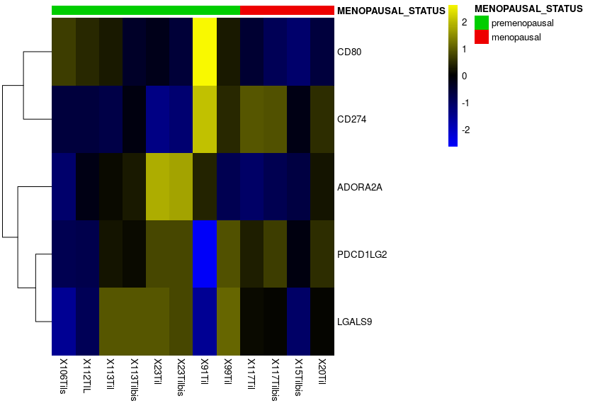

```r
SEobj2 <- SEobj[signatures$Davidson_suppressive,order(SEobj$MENOPAUSAL_STATUS)]
rownames(SEobj2) <- rowData(SEobj2)$geneName
sehm(SEobj2, rownames(SEobj2),assayName="vst", do.scale=TRUE, anno_columns = "MENOPAUSAL_STATUS",
     cluster_cols = params$cluster_cols, cluster_rows = T, show_colnames = T, anno_colors = list(MENOPAUSAL_STATUS=c(premenopausal="green3", menopausal="red2"))) # , anno_rows="meanTPM"
```

### costimulatory

```r
genes <- toupper(c("Cd86", "OX-40L", "4-1BBL", "Pvr", "Il1n", "Alcam", "Tnf"))
rowData(SEobj) %>% as.data.frame %>% filter(geneName %in% genes)
```

|  | gene_id | geneName | ENTREZID | description | Length | EffectiveLength |
| --- | --- | --- | --- | --- | --- | --- |
| ENSG00000073008 | ENSG00000073008 | PVR | 5817 | PVR cell adhesion molecule | 1655.95 | 1526.83 |
| ENSG00000114013 | ENSG00000114013 | CD86 | 942 | CD86 molecule | 1135.04 | 1006.01 |
| ENSG00000170017 | ENSG00000170017 | ALCAM | 214 | activated leukocyte cell adhesion molecule | 1769.89 | 1640.79 |
| ENSG00000232810 | ENSG00000232810 | TNF | 7124 | tumor necrosis factor | 1676.00 | 1546.88 |

```r
signatures$Davidson_costimulatory <- rowData(SEobj) %>% as.data.frame %>% filter(geneName %in% genes) %>% pull(gene_id)
```

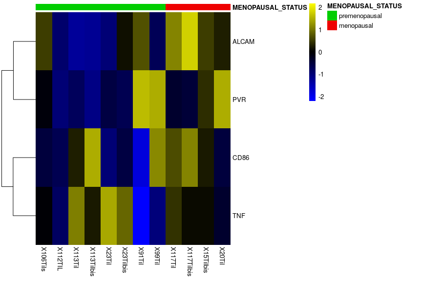

```r
SEobj2 <- SEobj[signatures$Davidson_costimulatory,order(SEobj$MENOPAUSAL_STATUS)]
rownames(SEobj2) <- rowData(SEobj2)$geneName
sehm(SEobj2, rownames(SEobj2),assayName="vst", do.scale=TRUE, anno_columns = "MENOPAUSAL_STATUS",
     cluster_cols = params$cluster_cols, cluster_rows = T, show_colnames = T, anno_colors = list(MENOPAUSAL_STATUS=c(premenopausal="green3", menopausal="red2"))) # , anno_rows="meanTPM"
```

## Characterization of regulatory B cells (yang frontiers in immunology 2021)

19 common genes significantly expressed, including Fcrl5, Zbtb20, Ccdc28b, Cd9, and Ptpn22 Gene sets for Breg cell definition

```r
genes <- c("FCRL5", "CD300LF", "CCR1", "PTPN22", "CD9", "CSF2RB",
           "S100A6", "PLAC8", "CCND2", "C130026I21RIK",
           "ZBTB20", "RILPL2", "APOE", "SP140", "SLC7A7", "RPLP0",
           "PDIA4", "CCDC28B", "MZB1")
# which(genes %in% rowData(SEobj)$geneName)
signatures$Yang_Bcells <- rowData(SEobj) %>% as.data.frame %>% filter(geneName %in% genes) %>% pull(gene_id)
```

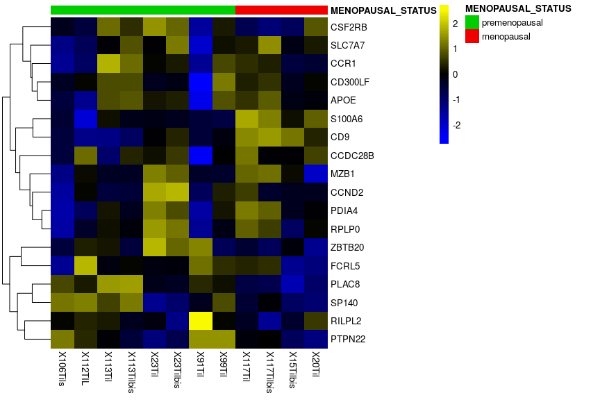

```r
SEobj2 <- SEobj[signatures$Yang_Bcells,order(SEobj$MENOPAUSAL_STATUS)]
rownames(SEobj2) <- rowData(SEobj2)$geneName
sehm(SEobj2, rownames(SEobj2),assayName="vst", do.scale=TRUE, anno_columns = "MENOPAUSAL_STATUS",
     cluster_cols = params$cluster_cols, cluster_rows = T, show_colnames = T, anno_colors = list(MENOPAUSAL_STATUS=c(premenopausal="green3", menopausal="red2"))) # , anno_rows="meanTPM"
```

## Cytolytic activity (Rooney 2015)

calculated as the geometric mean of GZMA and PRF1

```r
genes <- c("GZMA", "PRF1")
signatures$Rooney_cytolytic <- rowData(SEobj) %>% as.data.frame %>% filter(geneName %in% genes) %>% pull(gene_id)
```

```r
SEobj2 <- SEobj[signatures$Rooney_cytolytic,order(SEobj$MENOPAUSAL_STATUS)]
rownames(SEobj2) <- rowData(SEobj2)$geneName
if(length(signatures$Rooney_cytolytic)!=0){
  sehm(SEobj2, rownames(SEobj2),assayName="vst", do.scale=TRUE, anno_columns = "MENOPAUSAL_STATUS",
     cluster_cols = params$cluster_cols, cluster_rows = T, show_colnames = T, anno_colors = list(MENOPAUSAL_STATUS=c(premenopausal="green3", menopausal="red2"))) # , anno_rows="meanTPM"
}
```

[figure not shown]

## IFNy signature and Expanded immune signature (Ayers, McClanahan 2017)

```r
# ifng <- c("ID01", "CXCL10", "CXCL9", "HLA-DRA", "STAT1", "IFNG" )
genes <- c("CD3D", "IDO1", "CIITA", "CD3E", "CCL5", "GZMK", "CD2", "HLA-DRA", "CXCL13", "IL2RG", "NKG7", "HLA-E", "EXCR6", "LAG3", "TAGAP", "CXCL10", "STAT1", "GZMB") # extended signature
signatures$Ayers_IFNg <- rowData(SEobj) %>% as.data.frame %>% filter(geneName %in% genes) %>% pull(gene_id)
```

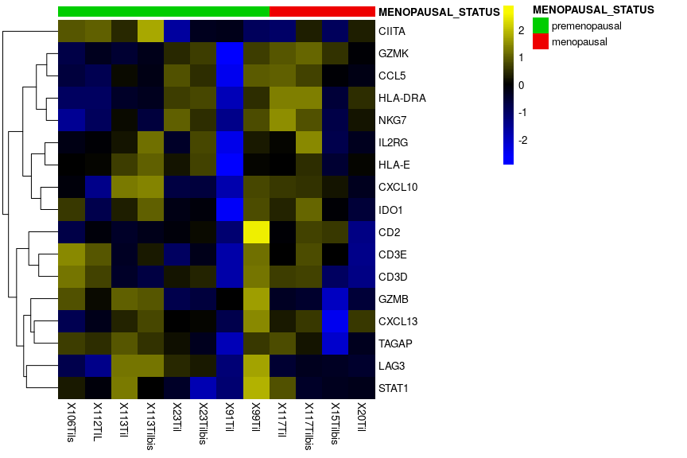

```r
SEobj2 <- SEobj[signatures$Ayers_IFNg,order(SEobj$MENOPAUSAL_STATUS)]
rownames(SEobj2) <- rowData(SEobj2)$geneName
sehm(SEobj2, rownames(SEobj2),assayName="vst", do.scale=TRUE, anno_columns = "MENOPAUSAL_STATUS",
     cluster_cols = params$cluster_cols, cluster_rows = T, show_colnames = T, anno_colors = list(MENOPAUSAL_STATUS=c(premenopausal="green3", menopausal="red2"))) # , anno_rows="meanTPM"
```

## Signature score with GSVA from the previous gene sets

```r
sig.mat <- gsva(SEobj, signatures, 'vst', method='gsva', kcdf="Gaussian", parallel.sz=8, mx.diff=F, tau=1, verbose=params$verbose)
```

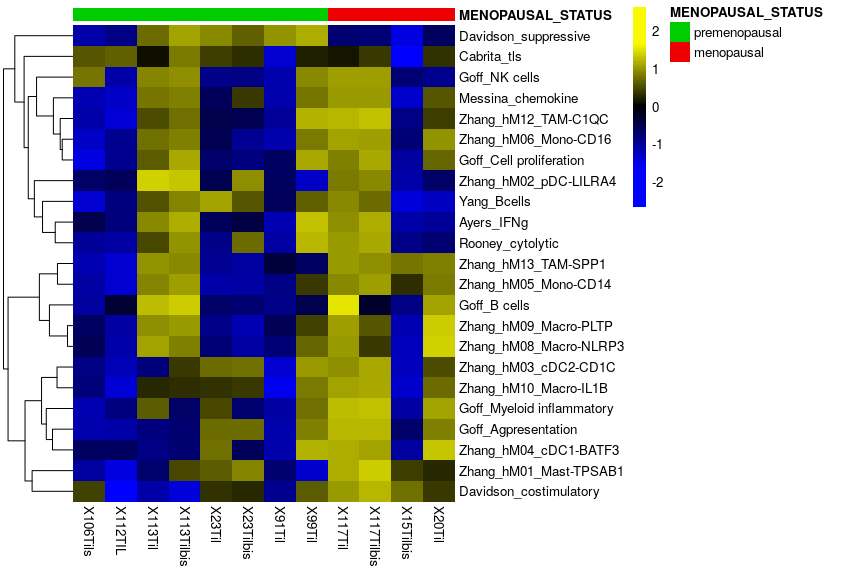

```r
sehm(sig.mat[,order(SEobj$MENOPAUSAL_STATUS)], rownames(sig.mat),assayName="es", do.scale=TRUE, anno_columns = "MENOPAUSAL_STATUS",
     cluster_cols = params$cluster_cols, cluster_rows = T, show_colnames = T, anno_colors = list(MENOPAUSAL_STATUS=c(premenopausal="green3", menopausal="red2"))) # , anno_rows="meanTPM"
```

```r
design <- model.matrix(~0+factor(sig.mat$MENOPAUSAL_STATUS))
colnames(design) <- c("menopausal", "premenopausal")
design
```

```
##    menopausal premenopausal
## 1           1             0
## 2           1             0
## 3           1             0
## 4           1             0
## 5           0             1
## 6           0             1
## 7           0             1
## 8           0             1
## 9           1             0
## 10          1             0
## 11          1             0
## 12          1             0
## attr(,"assign")
## [1] 1 1
## attr(,"contrasts")
## attr(,"contrasts")$`factor(sig.mat$MENOPAUSAL_STATUS)`
## [1] "contr.poly"
```

```r
cont_matrix <- makeContrasts(PostvsPre = menopausal-premenopausal, levels = design)
cont_matrix
```

```
##                Contrasts
## Levels          PostvsPre
##   menopausal            1
##   premenopausal        -1
```

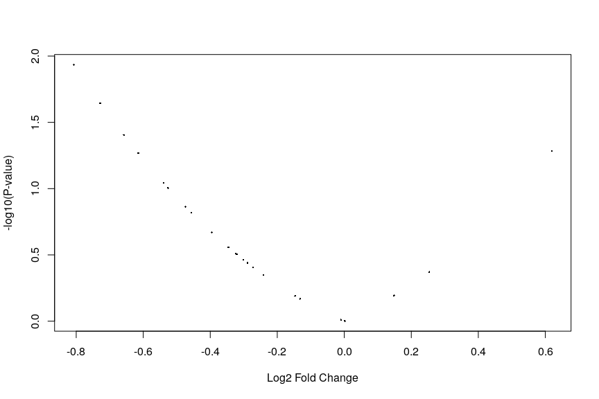

```r
# Fit the expression matrix to a linear model
fit <- lmFit(assay(sig.mat), design)
# Compute contrast
fit_contrast <- contrasts.fit(fit, cont_matrix)
# Bayes statistics of differential expression
# *There are several options to tweak!*
fit_contrast <- eBayes(fit_contrast)
# Generate a vocalno plot to visualize differential expression
volcanoplot(fit_contrast)
```

```r
# Generate a list of top 100 differentially expressed genes
top_genes <- topTable(fit_contrast, number = 100, adjust = "BH")
# Summary of results (number of differentially expressed genes)
result <- decideTests(fit_contrast)
summary(result)
```

```
##        PostvsPre
## Down           0
## NotSig        23
## Up             0
```

```r
top_genes
```

|  | logFC | AveExpr | t | P.Value | adj.P.Val | B |
| --- | --- | --- | --- | --- | --- | --- |
| Zhang_hM13_TAM-SPP1 | -0.807497187 | 0.030698348 | -2.543516122 | 0.01163055 | 0.2486642 | -2.820663 |
| Zhang_hM05_Mono-CD14 | -0.728370740 | 0.073228102 | -2.294277614 | 0.02267672 | 0.2486642 | -3.296475 |
| Davidson_costimulatory | -0.657945108 | 0.152583205 | -2.072445596 | 0.03933840 | 0.2486642 | -3.678730 |
| Davidson_suppressive | 0.619693741 | -0.017037720 | 1.951958527 | 0.05215679 | 0.2486642 | -3.870074 |
| Goff_Myeloid inflammatory | -0.614719487 | 0.016540519 | -1.936290244 | 0.05405743 | 0.2486642 | -3.894115 |
| Goff_Agpresentation | -0.539530408 | 0.038490896 | -1.699453958 | 0.09058568 | 0.3249123 | -4.233908 |
| Zhang_hM01_Mast-TPSAB1 | -0.526047019 | 0.054412929 | -1.656982952 | 0.09888636 | 0.3249123 | -4.290161 |
| Zhang_hM06_Mono-CD16 | -0.473856034 | 0.052485166 | -1.492587815 | 0.13691553 | 0.3876656 | -4.494482 |
| Zhang_hM04_cDC1-BATF3 | -0.456635702 | -0.014128548 | -1.438345901 | 0.15169524 | 0.3876656 | -4.557218 |
| Zhang_hM12_TAM-C1QC | -0.395683847 | 0.028913821 | -1.246355106 | 0.21390197 | 0.4919745 | -4.760617 |

[output cut: 13 more lines]

## ‘‘hallmark’’ gene sets (Liberzon , Cell Systems, 2015), signature score with GSVA

```r
SEobj <- readRDS(file.path(params$data_dir,params$file_name2))
SEobj$MENOPAUSAL_STATUS <- ordered(SEobj$MENOPAUSAL_STATUS, levels = c("premenopausal","menopausal"))
signatures <- list()
```

```r
require(msigdbr)
```

Which version of MSigDB was used?

This package was generated with MSigDB v7.5.1 (released January 2022). The MSigDB version is used as the base of the msigdsbr package version. You can check the installed version with packageVersion(“msigdbr”).

```r
hallmarks <- msigdbr(species = "Homo sapiens", category = "H")
```

```r
if(params$verbose) table(hallmarks$gs_name)
```

```r
signatures_H <- list()
for (n in unique(hallmarks$gs_name)) {
  signatures_H[[n]] <- hallmarks %>% filter(gs_name==n) %>% pull("ensembl_gene")
}
```

```r
sig.mat.H <- gsva(SEobj, signatures_H, 'vst', method='gsva', kcdf="Gaussian", parallel.sz=8, mx.diff=F, tau=1, verbose=params$verbose)
```

### heatmap with all hallmark sets

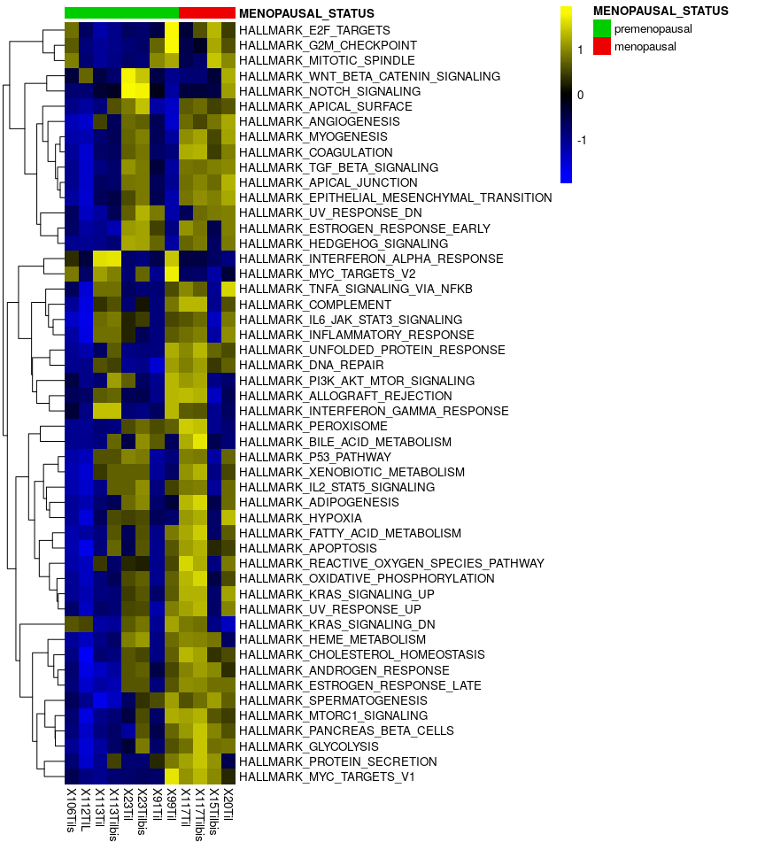

```r
sehm(sig.mat.H[,order(SEobj$MENOPAUSAL_STATUS)], rownames(sig.mat.H),assayName="es", do.scale=TRUE, anno_columns = "MENOPAUSAL_STATUS",
     cluster_cols = params$cluster_cols, cluster_rows = T, show_colnames = T, anno_colors = list(MENOPAUSAL_STATUS=c(premenopausal="green3", menopausal="red2"))) # , anno_rows="meanTPM"
```

```r
design <- model.matrix(~0+factor(sig.mat.H$MENOPAUSAL_STATUS))
colnames(design) <- c("premenopausal", "menopausal")
design
```

```
##    premenopausal menopausal
## 1              1          0
## 2              1          0
## 3              1          0
## 4              1          0
## 5              0          1
## 6              0          1
## 7              0          1
## 8              0          1
## 9              1          0
## 10             1          0
## 11             1          0
## 12             1          0
## attr(,"assign")
## [1] 1 1
## attr(,"contrasts")
## attr(,"contrasts")$`factor(sig.mat.H$MENOPAUSAL_STATUS)`
## [1] "contr.poly"
```

```r
cont_matrix <- makeContrasts(PostvsPre = menopausal-premenopausal, levels = design)
cont_matrix
```

```
##                Contrasts
## Levels          PostvsPre
##   premenopausal        -1
##   menopausal            1
```

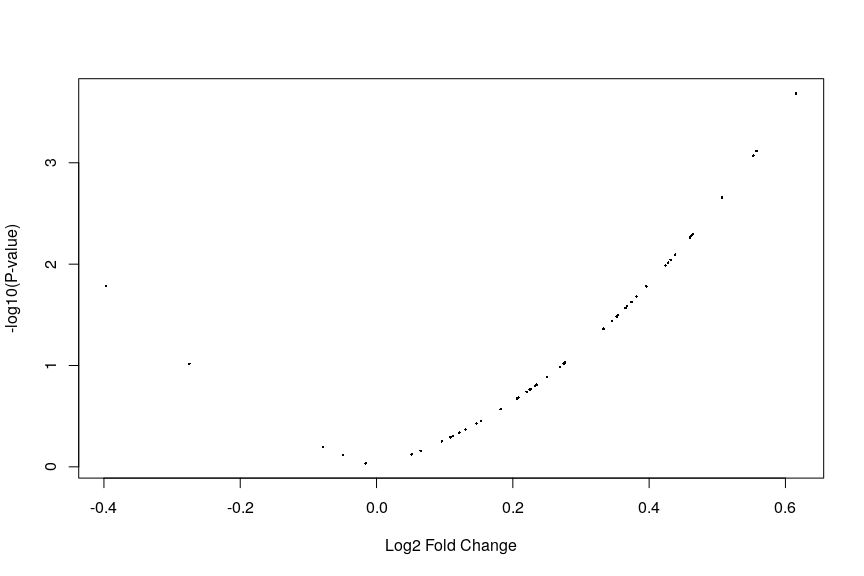

```r
# Fit the expression matrix to a linear model
fit <- lmFit(assay(sig.mat.H), design)
# Compute contrast
fit_contrast <- contrasts.fit(fit, cont_matrix)
# Bayes statistics of differential expression
# *There are several options to tweak!*
fit_contrast <- eBayes(fit_contrast)
# Generate a vocalno plot to visualize differential expression
volcanoplot(fit_contrast)
```

```r
# Generate a list of top 100 differentially expressed genes
top_genes <- topTable(fit_contrast, number = 100, adjust = "BH")
# Summary of results (number of differentially expressed genes)
result <- decideTests(fit_contrast)
summary(result)
```

```
##        PostvsPre
## Down           0
## NotSig        39
## Up            11
```

```r
top_genes
```

|  | logFC | AveExpr | t | P.Value | adj.P.Val | B |
| --- | --- | --- | --- | --- | --- | --- |
| HALLMARK_EPITHELIAL_MESENCHYMAL_TRANSITION | 0.61563468 | 0.0190536109 | 3.73754313 | 0.0002072802 | 0.01036401 | 0.4627618 |
| HALLMARK_COAGULATION | 0.55768323 | 0.0087069802 | 3.38571757 | 0.0007657978 | 0.01415381 | -0.7474712 |
| HALLMARK_ANGIOGENESIS | 0.55288324 | 0.0551040469 | 3.35657664 | 0.0008492289 | 0.01415381 | -0.8423510 |
| HALLMARK_PANCREAS_BETA_CELLS | 0.50682395 | 0.0155233641 | 3.07694882 | 0.0022059750 | 0.02757469 | -1.7110957 |
| HALLMARK_MYOGENESIS | 0.46373005 | 0.0118674729 | 2.81532401 | 0.0050651391 | 0.03898475 | -2.4555268 |
| HALLMARK_MYC_TARGETS_V1 | 0.46210816 | -0.0148459950 | 2.80547739 | 0.0052199916 | 0.03898475 | -2.4822537 |
| HALLMARK_MTORC1_SIGNALING | 0.45969970 | 0.0225595792 | 2.79085556 | 0.0054578650 | 0.03898475 | -2.5217692 |
| HALLMARK_GLYCOLYSIS | 0.43813907 | 0.0105226077 | 2.65996008 | 0.0080659180 | 0.04683393 | -2.8663166 |
| HALLMARK_CHOLESTEROL_HOMEOSTASIS | 0.43162585 | 0.0257129120 | 2.62041810 | 0.0090493585 | 0.04683393 | -2.9671457 |
| HALLMARK_TGF_BETA_SIGNALING | 0.42786942 | 0.0145954282 | 2.59761267 | 0.0096641625 | 0.04683393 | -3.0246113 |

[output cut: 40 more lines]

### heatmap with differential expressed hallmark sets

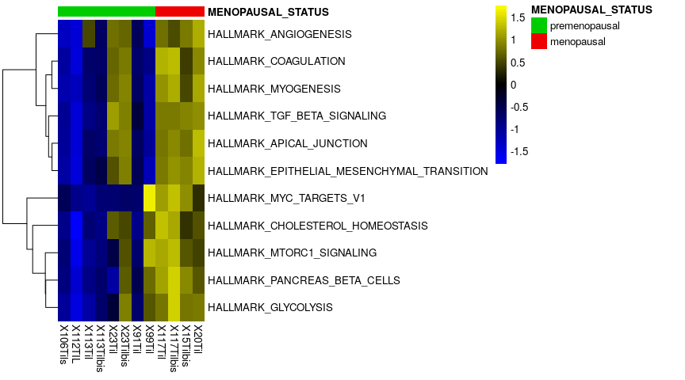

```r
sehm(sig.mat.H[ rownames(top_genes[which(top_genes$adj.P.Val<=0.05),]),order(SEobj$MENOPAUSAL_STATUS)], rownames(sig.mat.H),assayName="es", do.scale=TRUE, anno_columns = "MENOPAUSAL_STATUS",
     cluster_cols = params$cluster_cols, cluster_rows = T, show_colnames = T, anno_colors = list(MENOPAUSAL_STATUS=c(premenopausal="green3", menopausal="red2"))) # , anno_rows="meanTPM"
```

## ncloust Heatmap

```r
#x <- as.matrix(salmon_merged_gene_tpm[3:10])
#rownames(x) <- salmon_merged_gene_tpm$gene_id
#x <- x[rownames(dds),]
#exp.mat <- t(log2(x+1))

# x <- scale(t(as.matrix(TILS.exp)))
require(nclust)

annot = data.frame( status = as.character(sig.mat.H$MENOPAUSAL_STATUS),
                    id = sig.mat.H$names, row.names = sig.mat.H$files)

#mrtag=make_tag(annot, varnames=c("id","treatment"),cols=c("violet","green3"))
mrtag=make_tag(annot, varnames=c("status"),cols=c("green3"))
mrtag <- mrtag[,order(colnames(mrtag))]

myclust.TILS <- coldmap(t(assay(sig.mat.H)), rmarg=3, rtag = mrtag, rtag.space = 3)
```

[output not shown]

[output cut: 32 more lines]

[output not shown]

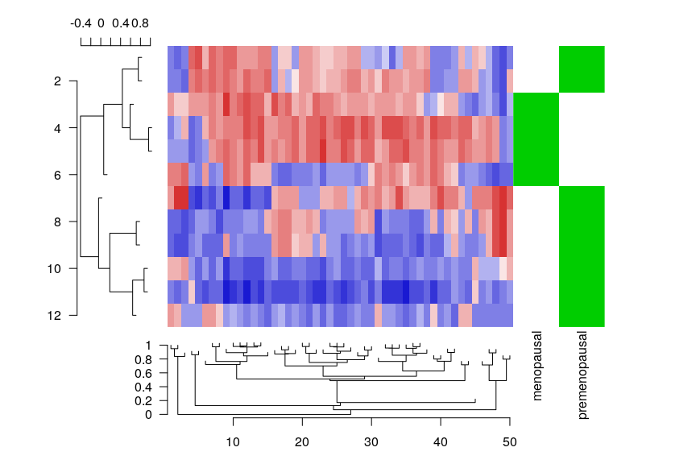

## Parameters

```r
print(params)
```

```
## $data_dir
## [1] "/export/scratch/pangelin/HUG/brca_nov2021/dgea/salmon/rdata"
##
## $file_name
## [1] "TILS.salmon.filt2.Rds"
##
## $file_name2
## [1] "TILS.salmon.filt.Rds"
##
## $verbose
## [1] FALSE
##
## $cluster_cols
## [1] FALSE
```